# Contents

1. Degree distribution
2. Power law
3. Clustering
4. Assortativity

```python
import networkx as nx
import numpy as np
import matplotlib as mpl
import matplotlib.pyplot as plt
%matplotlib inline

nx.__version__, mpl.__version__
```

```
('3.1', '3.5.2')
```

# 1. Degree distribution

We will first use [a large collaboration network of physicists from 1995 to 1999](http://www-personal.umich.edu/~mejn/netdata/cond-mat.zip) (Newman, 2001). As some physicists never colloborated with others, let us remove the isolated nodes representing them for simplicity. In addition, we will ignore the edges' weights (which Newman names as `value`).

```python
physicists = nx.convert_node_labels_to_integers(
    nx.read_gml('datasets/cond-mat.gml'), label_attribute='name')
# "cond-mat" stands for "condensed matter physics"

physicists.remove_nodes_from(list(nx.isolates(physicists)))
N = physicists.number_of_nodes()
E = physicists.number_of_edges()

print('number of nodes:', N)
print('number of edges:', E)
print('average degree : %.3g' % (sum(k for n, k in physicists.degree)/N))
```

```
number of nodes: 16264
number of edges: 47594
average degree : 5.85
```

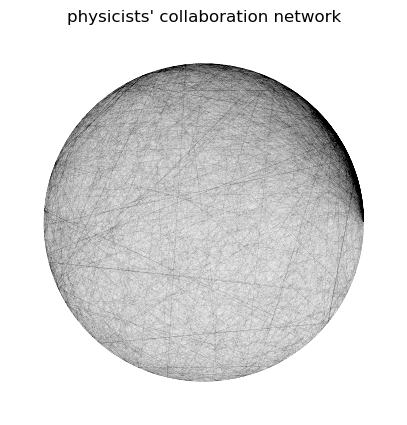

```python
plt.figure(figsize=(5, 5))
plt.title('physicists\' collaboration network')
nx.draw_circular(physicists, node_size=0, width=.05, alpha=.05)
# it is hard to draw a large network nicely
```

Degree distribution $P_k$ is an interesting quantity on large networks. When we plot it against degree $k$ for large **real networks**, we often see a **long tail**, which signifies a **power law**:

\begin{align} P_k \sim k^{-a} \quad \Leftrightarrow \quad \ln P_k \sim -a\ln k \quad \left(\text{for some }a>0\right)\,. \end{align}

We can justify whether the long tail indeed represents a power law by making a log-log plot of $P_k$ against $k$: a power law shows a negative slope.

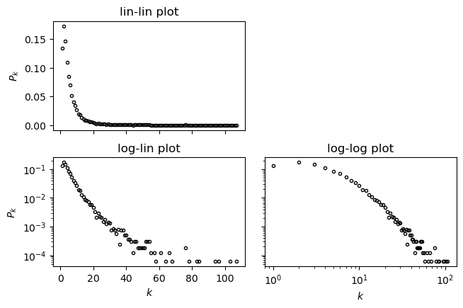

```python
degrees = [k for n, k in physicists.degree]
kMin, kMax = min(degrees), max(degrees)
kRng = np.arange(kMin, kMax+1)
degree_histogram = [n/N for n in nx.degree_histogram(physicists)[1:]]

fig, ax = plt.subplots(2, 2, sharex='col', sharey='row',
                       figsize=(3.5*(2+.1), 2*(2+.25)))
plt.subplots_adjust(wspace=.1, hspace=.25)
ax[0, 0].plot(kRng, degree_histogram, 'k.', mfc='none')
ax[0, 1].axis('off')
ax[1, 0].semilogy(kRng, degree_histogram, 'k.', mfc='none')
ax[1, 1].loglog(kRng, degree_histogram, 'k.', mfc='none')

ax[0, 0].set_title('lin-lin plot')
ax[1, 0].set_title('log-lin plot')
ax[1, 1].set_title('log-log plot')
for a in ax[1, :]: a.set_xlabel('$k$')
for a in ax[:, 0]: a.set_ylabel('$P_k$')
plt.show()
```

Is it trivial for a degree distribution to follow a power law? If we measure the degree distribution of all networks with $N$ nodes and $E$ edges, will we observe a power law frequently? We can answer this question by averaging the degree distributions of many random networks that each have $N$ nodes and $E$ edges. You can construct a random network with `n` nodes and `m` edges using `gnm_random_graph(n, m)`.

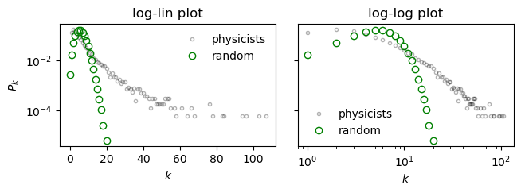

```python
rand_degrees, samples = [], 10
for sample in range(samples):
    random = nx.gnm_random_graph(N, E, seed=5056+sample)
    rand_degrees.extend([k for n, k in random.degree])
rand_degree_histogram = np.bincount(rand_degrees)/samples/N

fig, ax = plt.subplots(1, 2, sharey='row', figsize=(3.5*(2+.1), 2))
plt.subplots_adjust(wspace=.1)

ax[0].semilogy(kRng, degree_histogram, 'k.', mfc='none', alpha=.3)
ax[0].semilogy(rand_degree_histogram, 'go', mfc='none')
ax[1].loglog(kRng, degree_histogram, 'k.', mfc='none', alpha=.3)
ax[1].loglog(rand_degree_histogram, 'go', mfc='none')

ax[0].set_ylabel('$P_k$')
for a in ax: a.set_xlabel('$k$')
for a in ax: a.legend(['physicists', 'random'], frameon=False)
ax[0].set_title('log-lin plot')
ax[1].set_title('log-log plot')
plt.show()
```

It seems that it is no way common for a random network to generate a long-tailed degree distribution. This observation reveals the fact that **real networks are not random at all**. (You will learn more about random networks later.)

## 1.1 Binning

Although it is most faithful to plot $P_k$ at all available $k$, we usually bin the data before plotting. This has several advantages.

1. Binning smooths out local bumps of the distribution.
2. Binning removes excessive details concise when $k$ spans a wide range.
3. Binning reduces the chance of having zeros, i.e. $P_k=0$, which interrupt logarithmic plots.

However, we do not have a universal rule that determines how to bin data optimally, so binning inevitably introduces a lot of bias to our analysis. Check ["Histogram" on Wikipedia](https://en.wikipedia.org/wiki/Histogram#Number_of_bins_and_width) for more information.

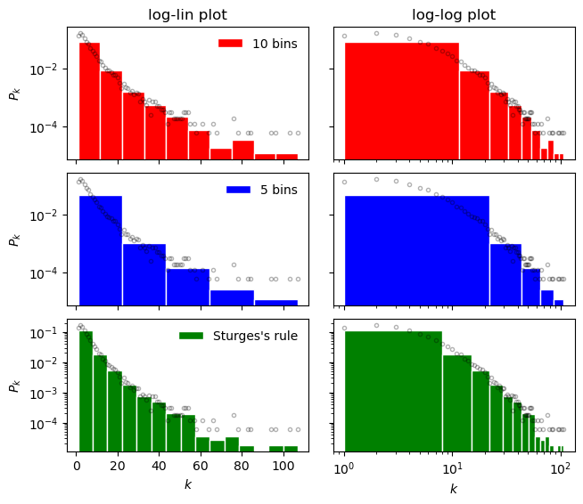

```python
fig, ax = plt.subplots(3, 2, sharex='col', sharey='row',
                       figsize=(3.5*(2+.1), 2*(3+.1)))
plt.subplots_adjust(wspace=.1, hspace=.1)
for r in ax:
    r[0].semilogy(kRng, degree_histogram, 'k.', mfc='none', alpha=.3)
    r[1].loglog(kRng, degree_histogram, 'k.', mfc='none', alpha=.3)

for c in ax.T:
    c[0].hist(degrees, bins=10, density=True,
              color='r', ec='w', lw=1, label='10 bins')
    c[1].hist(degrees, bins=5, density=True,
              color='b', ec='w', lw=1, label='5 bins')
    c[2].hist(degrees, bins='sturges', density=True,
              color='g', ec='w', lw=1, label='Sturges\'s rule')

for a in ax[2, :]: a.set_xlabel('$k$')
for a in ax[:, 0]: a.set_ylabel('$P_k$')
for a in ax[:, 0]: a.legend(frameon=False)
ax[0, 0].set_title('log-lin plot')
ax[0, 1].set_title('log-log plot')
plt.show()
```

Note that a log-log plot is distorted with linear binning because it excessively emphasizes data points at small $k$, so logarithmic binning should be used instead.

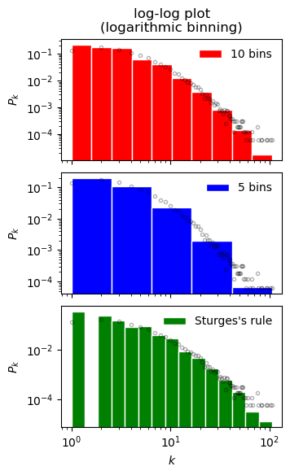

```python
fig, ax = plt.subplots(3, 1, sharex='col', figsize=(3.5, 2*(3+.1)))
plt.subplots_adjust(hspace=.1)
for a in ax: a.loglog(kRng, degree_histogram, 'k.', mfc='none', alpha=.3)

logBins = lambda bins: np.logspace(0, np.log10(kMax), bins+1)
ax[0].hist(degrees, bins=logBins(10), density=True,
           color='r', ec='w', lw=1, label='10 bins')
ax[1].hist(degrees, bins=logBins(5), density=True,
           color='b', ec='w', lw=1, label='5 bins')
ax[2].hist(degrees, bins=logBins(int(1+np.log2(N))+1), density=True,
           color='g', ec='w', lw=1, label='Sturges\'s rule')

ax[2].set_xlabel('$k$')
for a in ax: a.set_ylabel('$P_k$')
for a in ax: a.legend(frameon=False)
ax[0].set_title('log-log plot\n(logarithmic binning)')
plt.show()
```

Sometimes it looks nicer to show the bins with a curve that passes through their centres instead of drawing them out as rectangles.

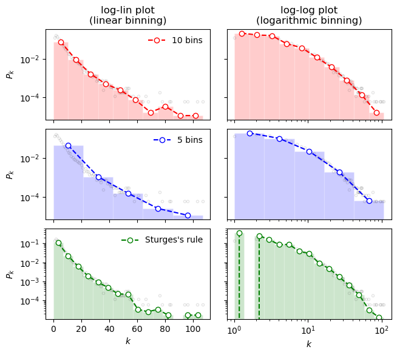

```python
def histogram(data, ax, c, log, bins, label):
    if log: # logarithmic binning
        binEdges = np.logspace(0, np.log10(kMax), bins+1)
        binCents = (binEdges[1:]*binEdges[:-1])**.5
    else:
        binEdges = np.linspace(0, kMax, bins+1)
        binCents = (binEdges[1:]+binEdges[:-1])*.5
    probs = np.histogram(data, bins=binEdges, density=True)[0]
    ax.plot(binCents, probs, c+'o--', mfc='w', label=label)
    ax.hist(data, bins=binEdges, density=True, alpha=.2, color=c, ec='w', lw=1)

fig, ax = plt.subplots(3, 2, sharex='col', sharey='row',
                       figsize=(3.5*(2+.1), 2*(3+.1)))
plt.subplots_adjust(wspace=.1, hspace=.1)
for r in ax:
    r[0].semilogy(kRng, degree_histogram, 'k.', mfc='none', alpha=.1)
    r[1].loglog(kRng, degree_histogram, 'k.', mfc='none', alpha=.1)
for col in range(2):
    histogram(degrees, ax[0, col], 'r', col, 10, '10 bins')
    histogram(degrees, ax[1, col], 'b', col, 5, '5 bins')
    histogram(degrees, ax[2, col], 'g', col, int(1+np.log2(N))+1, 'Sturges\'s rule')

for a in ax[2, :]: a.set_xlabel('$k$')
for a in ax[:, 0]: a.set_ylabel('$P_k$')
for a in ax[:, 0]: a.legend(frameon=False)
ax[0, 0].set_title('log-lin plot\n(linear binning)')
ax[0, 1].set_title('log-log plot\n(logarithmic binning)')
plt.show()
```

## 1.2 Complementary CDF

Alternatively, one may plot the complementary CDF of the degree distribution to avoid the subjectivity in binning. The complementary CDF is defined as $P\left(X>k\right)$, where $X$ denotes an arbitrary node's degree. If $P_k\sim k^{-a}$, its complementary also obeys a power law.

\begin{align} P\left(X>k\right) \sim \int_k^\infty x^{-a} d{x} \sim \left(x^{-a+1}\right)^\infty_k \sim k^{-a+1} \end{align}

While it obeys a power law like $P_k$, $P(X>k)$ is guaranteed to decrease monotonically, so it looks quite smooth even without binning. Furthermore, it definitely has no zeros at any $k\in\left[k_{\min}, k_{\max}\right)$, so we can plot its log-log plot safely.

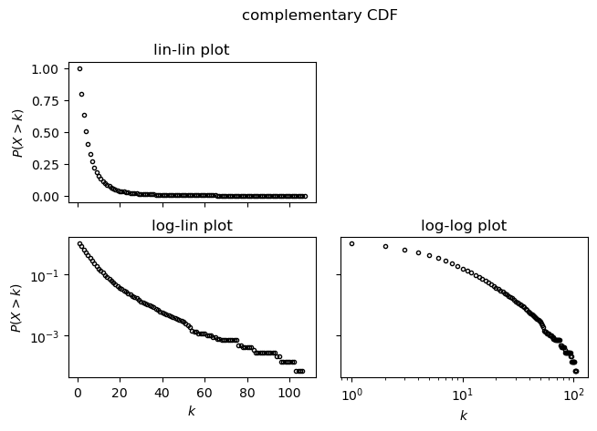

```python
cCDF = np.cumsum([0]+degree_histogram[:0:-1])[::-1]
cCDF = np.true_divide(cCDF, cCDF[0])

fig, ax = plt.subplots(2, 2, sharex='col', sharey='row',
                       figsize=(3.5*(2+.1), 2*(2+.25)))
plt.subplots_adjust(wspace=.1, hspace=.25)
ax[0, 0].plot(kRng, cCDF, 'k.', mfc='none')
ax[0, 1].axis('off')
ax[1, 0].semilogy(kRng, cCDF, 'k.', mfc='none')
ax[1, 1].loglog(kRng, cCDF, 'k.', mfc='none')

ax[0, 0].set_title('lin-lin plot')
ax[1, 0].set_title('log-lin plot')
ax[1, 1].set_title('log-log plot')
for a in ax[1, :]: a.set_xlabel('$k$')
for a in ax[:, 0]: a.set_ylabel('$P(X>k)$')
fig.suptitle('complementary CDF', y=1.01)
plt.show()
```

### Degree exponent.

The constant $a$ in $P_k\sim k^{-a}$ is called the degree exponent. A simple yet quite inaccurate way to measure it is to fit the complementary CDF with

\begin{align} \ln{P\left(X>k\right)} = \left({-a+1}\right)\ln{k} + b\,. \end{align}

You may also try to get a better estimate using some advanced techniques. Anyhow, network scientists are interested in this quantity because, as you will learn, it critically determines many properties of a network and thus classifies networks into various types.

```
a = 4.336743 ± 0.054163
b = 6.813736 ± 0.214798
```

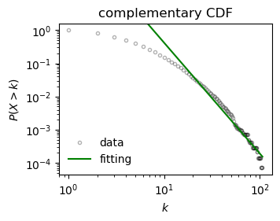

```python
from scipy.optimize import curve_fit
tail = 10 # the tail seems to start at k=10; a subjective choice
(a, b), pcov = curve_fit(
    lambda lnk, a, b: (-a+1)*lnk+b,
    np.log(kRng[tail:-1]), np.log(cCDF[tail:-1]))
print('a = %f ± %f' % (a, pcov[0, 0]**.5))
print('b = %f ± %f' % (b, pcov[1, 1]**.5))

plt.figure(figsize=(3.5, 2.5))
plt.loglog(kRng, cCDF, 'k.', mfc='none', alpha=.3, label='data')
ylim = plt.ylim()
plt.loglog(kRng, np.exp(b)*kRng**(-a+1), 'g-', label='fitting')
plt.ylim(ylim)
plt.legend(loc='lower left', frameon=False)
plt.xlabel('$k$')
plt.ylabel('$P(X>k)$')
plt.title('complementary CDF')
plt.show()
```

# 2. Power law

"Power law" is just a generic term. It describes any distribution that obeys $P(x)\sim x^{-a}$, but what does that little tilde "$\sim$" mean? To make the formula rigorous, we must specify a normalization constant $A$ to yield $P(x)=Ax^{-a}$ so that $\int_{-\infty}^{\infty}{P(x)dx}=1$. Then depending on whether $x$ is continuous or discrete, we obtain two kinds of power law.

### Pareto distribution.

If $x$ is continuous in $\left[m, \infty\right)$ for $m>0$, the normalization constant is

\begin{align} A = \left( \int_m^\infty {x^{-a}dx} \right)^{-1} = \left[ \left(\dfrac{x^{-a+1}}{-a+1}\right)^\infty_{m} \right]^{-1} = \dfrac{a-1}{m^{-a+1}}\,. \end{align}

This leads to the **continuous power law**, viz. the Pareto distribution. (Pareto was an Italian economist.) Conventionally, it is defined after shifting $a$ to $a+1$, giving

\begin{align} \mathrm{Pareto}\,{(x; a, m)} = \dfrac{(a+1)-1}{m^{-(a+1)+1}} x^{-(a+1)} = \dfrac{am^a}{x^{a+1}}\,. \end{align}

You can generate it with `stats.pareto` from SciPy, which sets $m=1$ by default.

### Zipf distribution.

In contrast, if $x$ is discrete in $\left[m, \infty\right)$ for $m>0$, the power law becomes the **discrete power law**, viz. the Zipf distribution. (Zipf was an American linguist.)

\begin{align} \mathrm{Zipf}\,{(x;a,m)} = \dfrac{x^{-a}}{\sum_{\xi=m}^\infty \xi^{-a}} \end{align}

Note that the distribution is undefined at $a=1$ as the denominator diverges. You can generate it with `stats.zipf` from SciPy, which also sets $m=1$ by default.

By the way, some people prefer the names "**zeta distribution**" or "**Zipf-Mandelbrot distribution**" instead. (They are formally a bit different, but they share the same spirit.)

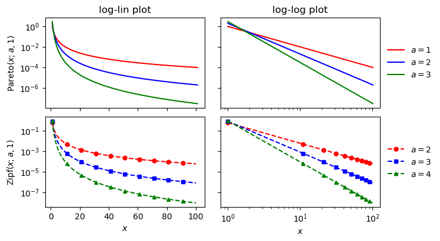

```python
from scipy.stats import pareto, zipf
m  = 1
xP = m + np.linspace(0, 100, 1000)
P  = lambda a: pareto.pdf(xP, a, loc=m-1)
xZ = m + np.arange(0, 100)
Z  = lambda a: zipf.pmf(xZ, a, loc=m-1)

fig, ax = plt.subplots(2, 2, sharex='col', sharey='row',
                       figsize=(3.5*(2+.1), 2*(2+.1)))
plt.subplots_adjust(wspace=.1, hspace=.1)

for a, c in zip([1, 2, 3], ['r','b','g']):
    ax[0, 0].semilogy(xP, P(a), c+'-', label='$a=%d$'%a)
    ax[0, 1].loglog  (xP, P(a), c+'-', label='$a=%d$'%a)
for a, fmt in zip([2, 3, 4], ['ro','bs','g^']):
    ax[1, 0].semilogy(xZ, Z(a), fmt+'--', ms=5, markevery=10, label='$a=%d$'%a)
    ax[1, 1].loglog  (xZ, Z(a), fmt+'--', ms=5, markevery=10, label='$a=%d$'%a)

for loc, a_ in zip(['upper right', 'lower left'], ax[:, 1]):
    a_.legend(loc='center left', bbox_to_anchor=(1, .5), frameon=False)
for a_ in ax[1]: a_.set_xlabel('$x$')
ax[0, 0].set_ylabel('$\mathrm{Pareto}(x; a, %d)$'%m)
ax[1, 0].set_ylabel('$\mathrm{Zipf}  (x; a, %d)$'%m)
ax[0, 0].set_title('log-lin plot')
ax[0, 1].set_title('log-log plot')
plt.show()
```

## 2.1 Relationship with exponential distribution

Power law contrasts with exponential distribution

\begin{align} \mathrm{Exp}\,{(x;a,m)} = ae^{-a(x-m)}\,, \end{align}

for which $x$ is continuous in $\left[m, \infty\right)$ for $m\geq0$. Although they show similar decreasing trends on a lin-lin plot, the tail of an exponential distribution decays much faster than that of a power law; in other words, $e^{-ax}\ll x^{-a}$ at large $x$.

You can generate it with `stats.expon` from Scipy.

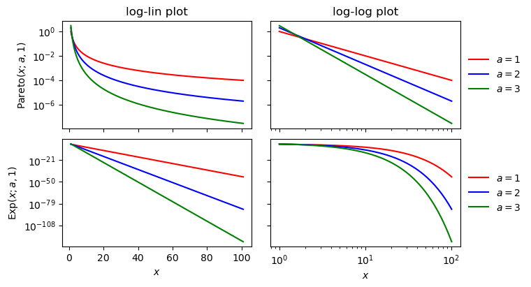

```python
from scipy.stats import expon
m = 1; x = m + np.linspace(0, 100, 1000)
E = lambda a: expon.pdf(x, loc=m, scale=1/a)

fig, ax = plt.subplots(2, 2, sharex='col', sharey='row',
                       figsize=(3.5*(2+.1), 2*(2+.1)))
plt.subplots_adjust(wspace=.1, hspace=.1)

for a, c in zip([1, 2, 3], ['r','b','g']):
    ax[0, 0].semilogy(x, P(a), c+'-', label='$a=%d$'%a)
    ax[0, 1].loglog  (x, P(a), c+'-', label='$a=%d$'%a)
    ax[1, 0].semilogy(x, E(a), c+'-', label='$a=%d$'%a)
    ax[1, 1].loglog  (x, E(a), c+'-', label='$a=%d$'%a)

for loc, a_ in zip(['upper right', 'lower left'], ax[:, 1]):
    a_.legend(loc='center left', bbox_to_anchor=(1, .5), frameon=False)
for a_ in ax[1]: a_.set_xlabel('$x$')
ax[0, 0].set_ylabel('$\mathrm{Pareto}(x; a, %d)$'%m)
ax[1, 0].set_ylabel('$\mathrm{Exp}   (x; a, %d)$'%m)
ax[0, 0].set_title('log-lin plot')
ax[0, 1].set_title('log-log plot')
plt.show()
```

### Crossover distributions.

What makes fitting a real degree distribution so difficult is the fact that they do not follow power law perfectly; instead, they often seem to be a mix of power law and exponential distribution. Hence, one may deliberately insert an **exponential cutoff** to the power law, getting

\begin{align} \mathrm{PowExp}\,{(x; a, b, m)} = A{\left(a, b, m\right)}\,x^{-a} e^{-bx}\,, \end{align}

and fit the degree distribution therewith instead. (Its normalization constant $A$ is complicated.) A formally simpler alternative is the **Weibull distribution**

\begin{align} \mathrm{Weibull}\,{(x; a, b, m)} = abe^{{\left(am\right)}^b} \left(ax\right)^{b-1} e^{-\left(ax\right)^b}\,. \end{align}

As the parameter $b$, which is known as the "stretching exponent", rises from $0$ to $1$, the Weibull distribution changes from a power law to an exponential distribution.

The distributions both support continuous $x$ in $\left[m, \infty\right)$ for $m\geq0$. If they are plotted on a log-log plot, they both look a straight line at small $x$ and turn into a curve at large $x$.

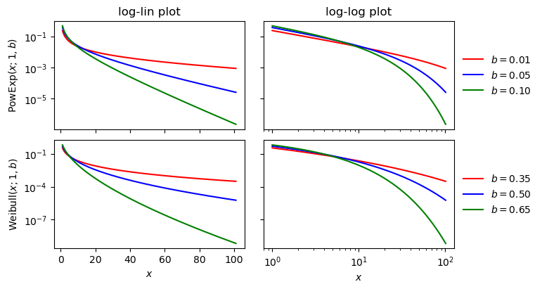

```python
from mpmath import gammainc as G
m  = 1; a = 1
x  = m + np.linspace(0, 100, 1000)
PE = lambda b: b**(1-a)/G(1-a, b*m) * x**-a * np.exp(-b*x)
W  = lambda b: a*b*np.exp((a*m)**b) * (a*x)**(b-1) * np.exp(-(a*x)**b)

fig, ax = plt.subplots(2, 2, sharex='col', sharey='row',
                       figsize=(3.5*(2+.1), 2*(2+.1)))
plt.subplots_adjust(wspace=.1, hspace=.1)
for b, c in zip([.01, .05, .1], ['r', 'b', 'g']):
    ax[0, 0].semilogy(x, PE(b), '-'+c, label='$b=%.2f$'%b)
    ax[0, 1].loglog  (x, PE(b), '-'+c, label='$b=%.2f$'%b)
for b, c in zip([.35, .5, .65], ['r', 'b', 'g']):
    ax[1, 0].semilogy(x, W (b), '-'+c, label='$b=%.2f$'%b)
    ax[1, 1].loglog  (x, W (b), '-'+c, label='$b=%.2f$'%b)

for loc, a_ in zip(['upper right', 'lower left'], ax[:, 1]):
    a_.legend(loc='center left', bbox_to_anchor=(1, .5), frameon=False)
for a_ in ax[1]: a_.set_xlabel('$x$')
ax[0, 0].set_ylabel('$\mathrm{PowExp} (x; %d, b)$'%a)
ax[1, 0].set_ylabel('$\mathrm{Weibull}(x; %d, b)$'%a)
ax[0, 0].set_title('log-lin plot')
ax[0, 1].set_title('log-log plot')
plt.show()
```

# 3. Clustering

Now let's shift our focus to [a semantic network of *David Copperfield*, Charles Dickens's novel](http://www-personal.umich.edu/~mejn/netdata/adjnoun.zip) (Newman, 2006). A node represents either an adjective or a noun, and two nodes are connected if one word follows the other word at least once in the novel.

(Newman's dataset equates a noun's plural form with its singular form, but this treatment will complicate our analysis later, so I am going to distinguish them and modify the network accordingly.The skills I use for the modification are beyond network science, so you do not need to understand them.)

```python
copperfield = nx.convert_node_labels_to_integers(
    nx.read_gml('datasets/adjnoun.gml'), label_attribute='word')

# the modification
import requests
from bs4 import BeautifulSoup
src = 'https://www.gutenberg.org/files/766/766-h/766-h.htm' # an online version
txt = '' # all words of David Copperfield
for div in BeautifulSoup(requests.get(src).text, 'html.parser'
                        ).find_all('div', {'class': 'chapter'}):
    if div.h2.text[:7] == 'CHAPTER':
        for p in div.find_all('p'):
            txt += p.text.strip('\r\n').replace('\r\n', ' ')

W  = nx.get_node_attributes(copperfield, 'word')
for u, v in copperfield.edges():
    if W[u]+' '+W[v] not in txt and W[v]+' '+W[u] not in txt:
        copperfield.remove_edge(u, v)

N = copperfield.number_of_nodes()
E = copperfield.number_of_edges()

print('number of nodes :', N)
print('number of edges :', E)
print('average degree  : %.3g' % (sum(k for n, k in copperfield.degree)/N))
```

```
number of nodes : 112
number of edges : 413
average degree  : 7.38
```

Note that the network is not bipartite although the nodes are classified into two classes.

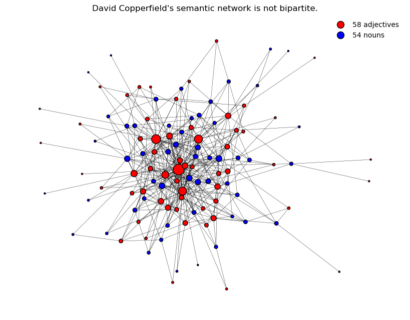

```python
adjs, nouns = nx.utils.groups(
    nx.get_node_attributes(copperfield, 'value')).values()
# value = 0 is an adjective; value = 1 is a noun

symbols = [plt.plot(0, 0, c+'o', ms=10, mec='k')[0] for c in ['r', 'b']]
plt.close()

plt.figure(figsize=(8, 6))
pos = nx.spring_layout(copperfield, seed=5056)
nx.draw(copperfield, pos=pos, edgecolors='k', width=.3,
        node_size=[copperfield.degree[n]*5 for n in copperfield],
        node_color=['r' if n in adjs else 'b' for n in copperfield])
plt.legend(symbols, ['%d adjectives' % len(adjs),
                     '%d nouns' % len(nouns)], loc='best', frameon=False)
plt.title('David Copperfield\'s semantic network is%s bipartite.'
          % ('' if nx.is_bipartite(copperfield) else ' not'))
plt.show()
```

We would like to quantify how clustered a network is, i.e. how much a node's neighbourhood correlates with those of its neighbours. A network without any clusters is essentially a tree, so trees cannot model social networks at all (otherwise it is impossible for two of your friends to be friends).

## 3.1 Clustering coefficient

A node's clustering coefficient measures how likely one of its neighbours is connected to another one. In other words, it is the **probability for a given node to form a triangle with two neighbours**. If a node's $k$ neighbours has $e$ edges among them, its clustering coefficient reads

\begin{align} c = \dfrac{2e}{k(k-1)}\,. \end{align}

As there are at most $k(k-1)\,/\,2$ edges among the $k$ neighbours, $c$ definitely lies within $\left[0, 1\right]$. The higher a node's clustering coefficient is, the more probably its neighbours are connected. You can compute a node's clustering coefficient with `clustering`, which returns a dictionary.

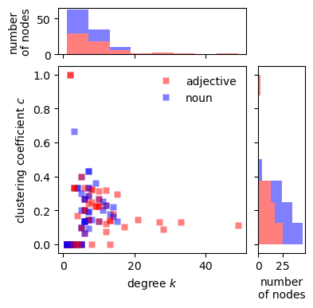

```python
c = lambda words: list(nx.clustering(copperfield, words).values())
k = lambda words: [copperfield.degree[word] for word in words]

fig = plt.figure(figsize=(4, 4))
gs = fig.add_gridspec(ncols=2, width_ratios =(4, 1), wspace=.1,
                      nrows=2, height_ratios=(1, 4), hspace=.1)
ax = np.empty((2, 2), dtype=object)

ax[0, 0] = fig.add_subplot(gs[0, 0])
ax[0, 0].hist([k(adjs), k(nouns)], 'sturges', color=['r', 'b'],
              stacked=True, alpha=.5)
ax[0, 0].set_xticklabels([])
ax[0, 0].set_ylabel('number\nof nodes')

ax[1, 1] = fig.add_subplot(gs[1, 1])
ax[1, 1].hist([c(adjs), c(nouns)], 'sturges', color=['r', 'b'],
              stacked=True, alpha=.5, orientation='horizontal')
ax[1, 1].set_xlabel('number\nof nodes')
ax[1, 1].set_yticklabels([])

ax[1, 0] = fig.add_subplot(gs[1, 0])
for word, (c_, k_) in enumerate(zip(c(copperfield), k(copperfield))):
    fmt = 'rs' if word in adjs else 'bs'
    ax[1, 0].plot(k_, c_, fmt, mec='none', alpha=.5)
# looks nicer than plotting all markers of
# a colour atop those of the other colour

ax[1, 0].legend(['adjective', 'noun'], frameon=False)
ax[1, 0].set_xlabel('degree $k$')
ax[1, 0].set_ylabel('clustering coefficient $c$')
plt.show()
```

## 3.2 Transitivity

A network's transitivity $T$ is the **probability for three nodes to form a triangle given that they have already formed a triad**, i.e. a V-shaped structure. (The lecture notes call it the global clustering coefficient $C_\Delta$.) Qualitatively, it means

\begin{align} T = 3\times\dfrac{\text{# triangles}}{\text{# triads}}\,, \end{align}

where the leading factor $3$ accounts for the fact that each triangle comprises three triads. One may refine the definition with the network's adjacency matrix $\mathbf{A}$:

\begin{align} T = \dfrac{\text{tr}\left(\mathbf{A}^3\right)} {\sum_{i\neq j}\left(\mathbf{A}^2\right)_ {ij}}\,. \end{align}

Try to reason why the two defintions are equivalent. You can compute the quantity with `transitivity`.

```python
nx.transitivity(copperfield)
```

```
0.15381672087239334
```

While some people define a **network's clusetering coefficient** with the transitivity $T$, some other people define it with the nodes' average clustering coefficeint $\langle c\rangle$, which you can compute with `average_clustering`.

```python
nx.average_clustering(copperfield)
```

```
0.16709731539413405
```

The two quantities are generally different although they both count triangles. Such a quantitative difference arises due to their formal difference. On one hand,

\begin{align} T \sim \dfrac{\sum_i \text{# triangles involving $i$}} {\sum_i \text{# triads involving $i$}}\,; \end{align}

on the other hand,

\begin{align} \langle{c}\rangle \sim \sum_i \dfrac{\text{# triangles involving $i$}} {\text{# triads involving $i$}}\,. \end{align}

The former is a ratio of sums, whereas the latter is an average of fractions.

## 3.3 Reciprocity

On a directed network, you may measure reciprocity $R$, i.e. the probability that an edge from a node to another implies the reverse edge.

\begin{align} R = \dfrac{1}{2E}\,\mathrm{tr}{\left(\mathbf{A}\,\mathbf{A}^\top\right)} \end{align}

You can compute it with `reciprocity`. In principle, an undirected network's reciprocity is one because an undirected edge can be interpreted as a bidirected edge, but `reciprocity` returns zero if the input network is undirected.

Now I will create a directed version of David Copperfield's semantic network: a node links to another node if the former's word precedes the latter's word at least once in the novel.

```python
copperfield_D = nx.DiGraph()
for u, v in copperfield.edges:
    if W[u]+' '+W[v] in txt: copperfield_D.add_edge(u, v)
    if W[v]+' '+W[u] in txt: copperfield_D.add_edge(v, u)

nx.reciprocity(copperfield_D)
```

```
0.11845102505694761
```

# 4. Assortativity

Assortativity measures how a node's identity affects its neighbourhood. An **assortative** network has **homophilic** nodes that tend to connect with similar nodes. In contrast, a **dissortative** network has **heterophilic** nodes that tend to connect with dissimilar nodes.

Assortativity is divided into two types based on how "similarity" is defined.

## 4.1 Categorical assortativity

Categorical assortativity defines similiarity between nodes by their **categorical attirbutes** (or "enumerative characteristics" according to the lecture notes) likes colours. First consider a directed network with $N$ nodes. If the nodes are classified into $p$ classes, the network's **assortativity coefficient** reads

\begin{align} r_c = \dfrac{\sum_{s=1}^p {e_{ss} - a_sb_s}} {1-\sum_{s=1}^p {a_sb_s}}\,, \end{align}

where

- $e_{ss}$ is the fraction of edges connecting two nodes of the same class $s$;
- $a_s=\sum_t{e_{st}}$ is the fraction of edges starting from a node in class $s$; and
- $b_s=\sum_t{e_{ts}}$ is the fraction of edges ending at a node in class $s$.

If the network is undirected, $e_{st}=e_{ts}$, making $a_s=b_s$ and $a_sb_s=a_s^2$. You can compute $r_c$ with `attirbute_assortativity_coefficient`.

```python
nx.attribute_assortativity_coefficient(copperfield, 'value')
```

```
-0.513352456741001
```

The coefficient has a range $r_c\in\left[-1, 1\right]$. A network is assortative if $r_c > 0$, otherwise it is dissortative. The semantic network is dissortative because $r_c < 0$. It means that most of its edges connect nodes of different classes, i.e. an adjective and a noun (instead of two adjectives or two nouns).

- If a network only connects nodes that have the same class, it is perfectly assortative and yields $r_c=1$.
- If a network's edges do not depend on the nodes' classes at all, it is neutral and yields $r_c=0$.
- If a network only connects nodes that have distinct classes, it is perfectly dissortative, but it yields $r_c\in\left[-1, 0\right)$ instead of strictly $r_c=-1$. This means that a neutral network is "closer" to a perfectly dissortative network than to a perfectly assortative network. You may read [Newman (2003)](https://journals.aps.org/pre/abstract/10.1103/PhysRevE.67.026126) for a more theoretical discussion on this phenomenon.

### Modularity.

For an undirected network, the numerator of $r_c$ in the formula above is called modularity $M$. You may treat it as an unnormalized version of the categorical assortativity at this moment, but you will see its significance in Tutorial 5. We can compute it with

\begin{align} M = \sum_{s=1}^p {e_{ss} - a_sb_s} \equiv \mathrm{tr}{\,\mathbf{e}} - \lVert{ \mathbf{e}^2 }\rVert\,, \end{align}

where $\mathbf{e}\equiv\left(e_{ij}\right)$ and $\lVert\cdot\rVert$ sums up the elements of a matrix. You can get $\mathbf{e}$ by calling `attribute_mixing_matrix`.

```python
e = nx.attribute_mixing_matrix(copperfield, 'value')
M = e.trace()-np.sum(e@e); M
```

```
-0.24393940282231819
```

More fundamentally speaking, modularity is defined as

\begin{align} M = \dfrac{1}{2E} \sum_i \sum_j { \left({ A_{ij} - \dfrac{k_ik_j}{2E} }\right) \delta{\left({c_i, c_j}\right)}}\,, \end{align}

where node $i$ has degree $k_i$ and class $c_i$, and $E$ is the number of edges. It uses the Kronecker delta function $\delta{\left(x,y\right)}=\begin{cases} 1 & \left(x=y\right) \\ 0 & \left(x\neq y\right)\end{cases}$. The two formulations can be shown equivalent after doing some algebra. We can then replace the summations by a modularity matrix

\begin{align} \mathbf{B} = \mathbf{A}-\dfrac{1}{2E}\,\mathbf{k}\,\mathbf{k}^\top\,, \end{align}

a degree vector $\mathbf{k}=\left(\matrix{k_1 \\ \vdots \\ k_N}\right)$, and a class matrix $\mathbf{C}_{N\times p}\equiv\left(C_{is}\right)$ with $C_{is}\equiv\delta{\left(c_i, s\right)}$ (i.e. whether node $i$ is in class $s$), finally resulting in

\begin{align} M = \dfrac{1}{2E}\, \mathrm{tr}{\,\left( \mathbf{C}^\top \mathbf{B} \, \mathbf{C}\right) }\,. \end{align}

You can get the modularity matrix $\mathbf{B}$ with `modularity_matrix`.

```python
B = nx.modularity_matrix(copperfield)
C = np.array([[i in c for c in [adjs, nouns]] for i in copperfield])
M = (np.trace(C.T@B@C) / (2*E)).item(); M
```

```
-0.2439394028223182
```

## 4.2 Quantitative assortativity

Quantitative assortativity is associated with some **quantitative attributes** (or "scalar characteristics" according to the lecture notes) like degree. One may simply measure it with the Pearson correlation coefficient:

\begin{align} r_q = \dfrac{\langle xy \rangle - \langle x \rangle \langle y \rangle} {\sqrt{\langle x^2 \rangle - \langle x \rangle^2} \sqrt{\langle y^2 \rangle - \langle y \rangle^2}}\,. \end{align}

The averages $\langle\cdot\rangle$ run through all edges, each of which connects node $i$ that has $q_i=x$ to another node $j$ that has $q_j=y$. You can compute $r_q$ with `numeric_assortativity_coefficient`; in particular, you may use `degree_assortativity_coefficient` if the characteristic that you are measuring is a node's degree.

```python
for n, d in physicists.nodes(data=True):
    d['degree'] = physicists.degree[n]

(nx.numeric_assortativity_coefficient(physicists, 'degree'),
 nx.degree_assortativity_coefficient(physicists))
```

```
(0.184637988036736, 0.184637988036736)
```

As its degree assortativity coefficient $r_k \equiv r_{q=k}>0$ is positive, the colloboration network is assortative in terms of degree. It implies that the physicists generally prefered to work with people who had similar levels of fame or reputation.

An alternative definition of $r_q$ employs the modularity matrix $\mathbf{B}$ and the Laplacian matrix $\mathbf{L}$.

\begin{align} r_q = \dfrac{\mathbf{q}^\top\,\mathbf{B}\,\mathbf{q}} {\mathbf{q}^\top\left(\mathbf{B}+\mathbf{L}\right)\mathbf{q}} \quad\text{for}\quad \mathbf{q} = \left(\matrix{q_1\\\vdots\\q_N}\right) \end{align}

```python
B = nx.modularity_matrix(copperfield)
L = nx.laplacian_matrix(copperfield)
q = np.array([[k] for n, k in copperfield.degree])
r = ((q.T@B@q) / (q.T@(B+L)@q)).item()
(nx.degree_assortativity_coefficient(copperfield), r)
```

```
(-0.13812160525825995, -0.13812160525826014)
```

### Degree correlation function.

In addition to measuring $r_k$, one may study a network's degree assortativity by measuring its degree correlation function $k^\prime{\left(k\right)}$, which is defined as the expected degree of a $k$-degree node's neighbour:

\begin{align} {k^\prime}(k) = \dfrac{\sum_i k^\prime_i\,\delta{\left(k_i, k\right)}} {\sum_i \delta{\left(k_i, k\right)}}\,, \end{align}

where $k_i$ and $k^\prime_i=\langle{A_{ij}k_j}\rangle$ are respectively the degree of node $i$ and the average degree of its neighbours. Since neighbours on an assortative network tend to have similar degrees, $k^\prime$ should increase with $k$, otherwise $k^\prime$ should decrease as $k$ grows.

You can compute $k^\prime$ with `average_degree_connectivity`.

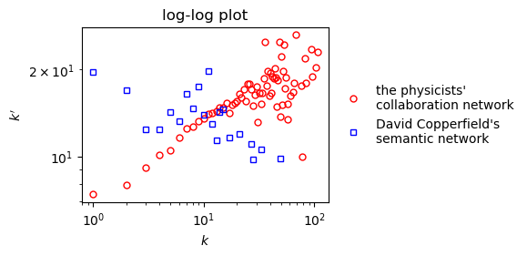

```python
plt.figure(figsize=(3.5, 2.5))
for G, fmt in zip([physicists, copperfield], ['ro', 'bs']):
    k = nx.average_degree_connectivity(G)
    plt.loglog(k.keys(), k.values(), fmt, ms=5, mfc='none')
plt.xlabel('$k$')
plt.ylabel('$k^\prime$')
plt.title('log-log plot')
plt.legend(['the physicists\'\ncollaboration network',
            'David Copperfield\'s\nsemantic network'],
           loc='center left', bbox_to_anchor=(1, .5), frameon=False)
plt.show()
```

The collaboration network is assortative because its $k^\prime$ increases with $k$, whereas the semantic network is dissortative because of its opposite trend. Both observations agree with the results suggested by $r_k$.

In fact, $k^\prime$ and $r_k$ are related to each other with a complicated relationship: although their agreement is not coincidental, they imply distinct philosophies. You may read [Barabási's Chapter 7 (2016)](http://networksciencebook.com/chapter/7) for a rigorous discussion.

# References

1. Barabási A.-L. (2016) *Network Science* (Cambridge University Press, Cambridge).
2. Newman M. E. J. (2001) *The structure of scientific collaboration networks*, Proc. Natl. Acad. Sci. U.S.A. **98**, 404.
3. Newman M. E. J. (2003) *Mixing patterns in networks*, Phys. Rev. E **67**, 026126.
4. Newman M. E. J. (2006) *Finding community structure in networks using the eigenvectors of matrices*, Phys. Rev. E **74**, 036104.